# Group6_CSCN8010_Final_Project

### Model Building - Original Data

```python
models = []  # Empty list to store all the models

# Appending models into the list
models.append(("Bagging", BaggingClassifier(random_state=1)))
models.append(("Random forest", RandomForestClassifier(random_state=1)))
models.append(("GBM", GradientBoostingClassifier(random_state=1)))
models.append(("Adaboost", AdaBoostClassifier(random_state=1)))
models.append(("dtree", DecisionTreeClassifier(random_state=1, class_weight='balanced')))

print("\n" "Training Performance:" "\n")
for name, model in models:
    model.fit(X_train, y_train)
    scores = recall_score(y_train, model.predict(X_train))
    print("{}: {}".format(name, scores))

print("\n" "Validation Performance:" "\n")

for name, model in models:
    model.fit(X_train, y_train)
    scores_val = recall_score(y_val, model.predict(X_val))
    print("{}: {}".format(name, scores_val))
```

```
Training Performance:

Bagging: 0.9379554855229466
Random forest: 1.0
GBM: 0.4920228481386646
Adaboost: 0.4230844987197164
dtree: 1.0

Validation Performance:

Bagging: 0.45067926757235677
Random forest: 0.4861193148257531
GBM: 0.5062020082693444
Adaboost: 0.4477259303012404
dtree: 0.470761961015948
```

Looking at the performance on the validation test, we can see that

GBM has the best performance , followed by Random Forest.

Lets Check the confusion matrix for train and validation datasets

```
Confusion Matrix for training data
```

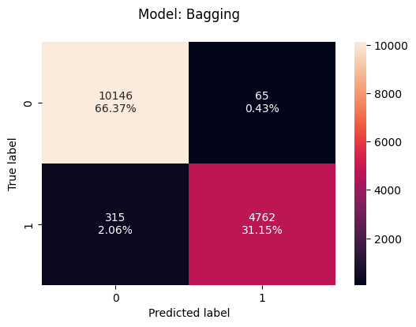

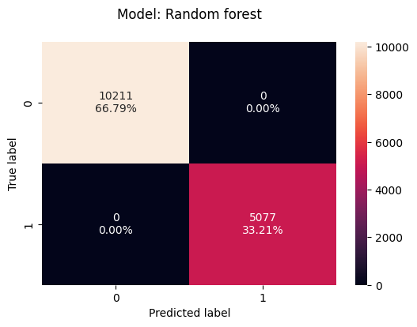

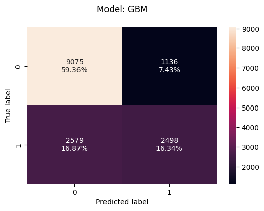

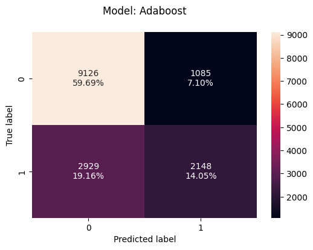

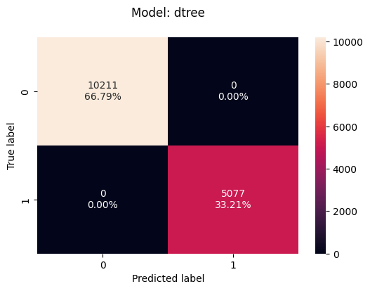

```python
print("Confusion Matrix for training data")
for name, model in models:
  confusion_matrix_sklearn(model, X_train, y_train)
  plt.title(f"Model: {name}\n")
```

```
Confusion Matrix for validation data
```

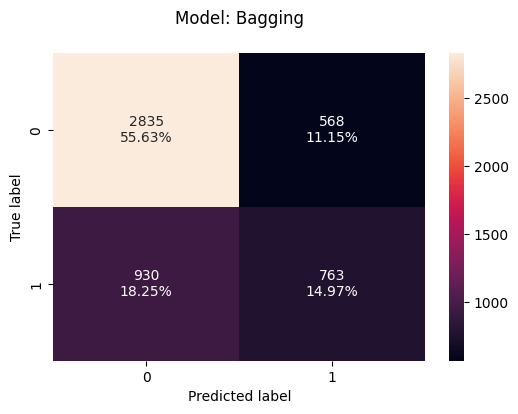

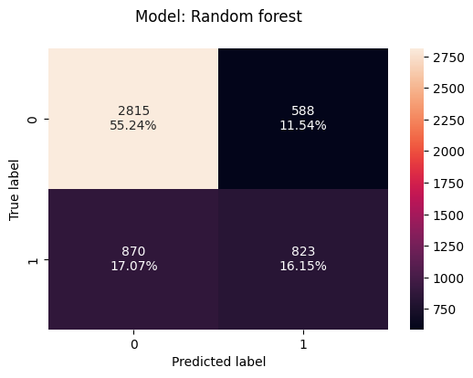

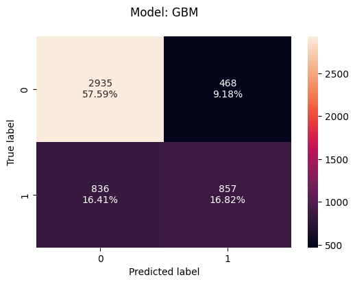

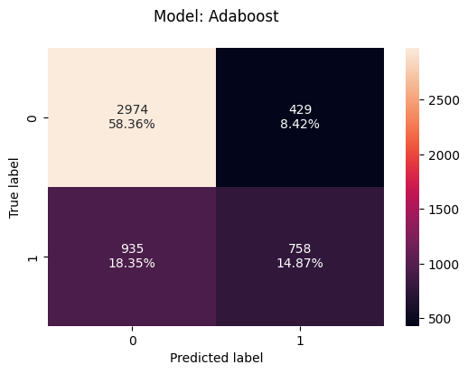

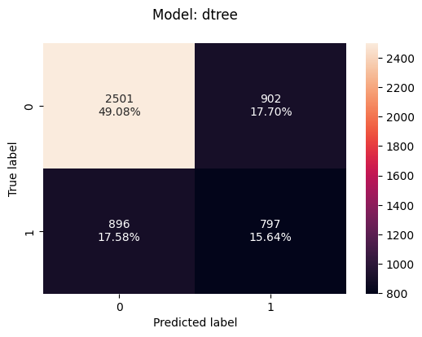

```python
print("Confusion Matrix for validation data")
for name, model in models:
  confusion_matrix_sklearn(model, X_val, y_val)
  plt.title(f"Model: {name}\n")
```

### Model Building - Oversampled Data

```python
print("Before Oversampling, counts of label 'Yes': {}".format(sum(y_train == 1)))
print("Before Oversampling, counts of label 'No': {} \n".format(sum(y_train == 0)))

sm = SMOTE(
    sampling_strategy=1, k_neighbors=5, random_state=1
)  # Synthetic Minority Over Sampling Technique
X_train_over, y_train_over = sm.fit_resample(X_train, y_train)


print("After Oversampling, counts of label 'Yes': {}".format(sum(y_train_over == 1)))
print("After Oversampling, counts of label 'No': {} \n".format(sum(y_train_over == 0)))


print("After Oversampling, the shape of train_X: {}".format(X_train_over.shape))
print("After Oversampling, the shape of train_y: {} \n".format(y_train_over.shape))
```

```
Before Oversampling, counts of label 'Yes': 5077
Before Oversampling, counts of label 'No': 10211

After Oversampling, counts of label 'Yes': 10211
After Oversampling, counts of label 'No': 10211

After Oversampling, the shape of train_X: (20422, 22)
After Oversampling, the shape of train_y: (20422,)
```

```python
models = []  # Empty list to store all the models

# Appending models into the list
models.append(("Bagging", BaggingClassifier(random_state=1)))
models.append(("Random forest", RandomForestClassifier(random_state=1)))
models.append(("GBM", GradientBoostingClassifier(random_state=1)))
models.append(("Adaboost", AdaBoostClassifier(random_state=1)))
models.append(("dtree", DecisionTreeClassifier(random_state=1, class_weight='balanced')))


print("\n" "Training Performance:" "\n")
for name, model in models:
    model.fit(X_train_over, y_train_over)
    scores = recall_score(y_train_over, model.predict(X_train_over))
    print("{}: {}".format(name, scores))

print("\n" "Validation Performance:" "\n")

for name, model in models:
    model.fit(X_train_over, y_train_over)
    scores = recall_score(y_val, model.predict(X_val))
    print("{}: {}".format(name, scores))
```

```
Training Performance:

Bagging: 0.9735579277250025
Random forest: 1.0
GBM: 0.7281363235726178
Adaboost: 0.6652629517187347
dtree: 1.0

Validation Performance:

Bagging: 0.4500886001181335
Random forest: 0.5191966922622564
GBM: 0.5410513880685174
Adaboost: 0.4607206142941524
dtree: 0.5044300059066745
```

GBM has the best performance on the validation set, followed by Random forest

### Model Building - Undersampled Data

```python
rus = RandomUnderSampler(random_state=1)
X_train_un, y_train_un = rus.fit_resample(X_train, y_train)
```

```python
print("Before Under Sampling, counts of label 'Yes': {}".format(sum(y_train == 1)))
print("Before Under Sampling, counts of label 'No': {} \n".format(sum(y_train == 0)))

print("After Under Sampling, counts of label 'Yes': {}".format(sum(y_train_un == 1)))
print("After Under Sampling, counts of label 'No': {} \n".format(sum(y_train_un == 0)))

print("After Under Sampling, the shape of train_X: {}".format(X_train_un.shape))
print("After Under Sampling, the shape of train_y: {} \n".format(y_train_un.shape))
```

```
Before Under Sampling, counts of label 'Yes': 5077
Before Under Sampling, counts of label 'No': 10211

After Under Sampling, counts of label 'Yes': 5077
After Under Sampling, counts of label 'No': 5077

After Under Sampling, the shape of train_X: (10154, 22)
After Under Sampling, the shape of train_y: (10154,)
```

```python
models = []  # Empty list to store all the models

# Appending models into the list
models.append(("Bagging", BaggingClassifier(random_state=1)))
models.append(("Random forest", RandomForestClassifier(random_state=1)))
models.append(("GBM", GradientBoostingClassifier(random_state=1)))
models.append(("Adaboost", AdaBoostClassifier(random_state=1)))
models.append(("dtree", DecisionTreeClassifier(random_state=1, class_weight='balanced')))


print("\n" "Training Performance:" "\n")
for name, model in models:
    model.fit(X_train_un, y_train_un)
    scores = recall_score(y_train_un, model.predict(X_train_un))  ## Complete the code to build models on undersampled data
    print("{}: {}".format(name, scores))

print("\n" "Validation Performance:" "\n")

for name, model in models:
    model.fit(X_train_un, y_train_un)
    scores = recall_score(y_val, model.predict(X_val))
    print("{}: {}".format(name, scores))
```

```
Training Performance:

Bagging: 0.9694701595430373
Random forest: 0.9998030332873744
GBM: 0.7153831002560568
Adaboost: 0.6826866259602127
dtree: 1.0

Validation Performance:

Bagging: 0.6219728292971057
Random forest: 0.6857649143532192
GBM: 0.7123449497932663
Adaboost: 0.6993502658003544
dtree: 0.6125221500295334
```

GBM has the best performance in the validation dataset followed by Adaboost

So, highest recalls

GBM With Undersampling : 71%

Adaboost with undersampling : 69.9%

GBM with Oversampling :54%

Random forest with oversampling: 51%

So, we will use

1. GBM with undersampled data, Ada Boost with undersampled and GBM with over sampled data models exhibited strong performance on the validation data.
2. We will tune the above models to avoid overfitting and underfitting and get the generalized models.
3. we will tune these 3 models using the same data ( undersampled and oversampled) as we trained on them before.

### Hyperparameter Tuning

#### Tuning AdaBoost using original data

NOTE:

The hyperparameters in the param_Grid of hyperparameter values in the code below are obtained after researching and speaking with the subject matter experts.

GridSearchCV( method, to extract the best hyperparamenter values, is expensive and very time consuming. Hence RandomSearchCV function is used.

```python
%%time

# defining model
Model = AdaBoostClassifier(random_state=1)

# Parameter grid to pass in RandomSearchCV : Used the below param_Grid from the Notebook provided by the instructor from the MLS 3 session
param_grid = {
    "n_estimators": np.arange(10, 40, 10),
    "learning_rate": [0.1, 0.01, 0.2, 0.05, 1],
    "estimator": [
        DecisionTreeClassifier(max_depth=1, random_state=1),
        DecisionTreeClassifier(max_depth=2, random_state=1),
        DecisionTreeClassifier(max_depth=3, random_state=1),
    ],
}

# Type of scoring used to compare parameter combinations
scorer = metrics.make_scorer(metrics.recall_score)

#Calling RandomizedSearchCV
randomized_cv = RandomizedSearchCV(estimator=Model, param_distributions=param_grid, n_jobs = -1, n_iter=50, scoring=scorer, cv=5, random_state=1)

#Fitting parameters in RandomizedSearchCV
randomized_cv.fit(X_train, y_train)

print("Best parameters are {} with CV score={}:" .format(randomized_cv.best_params_,randomized_cv.best_score_))
```

```
Best parameters are {'n_estimators': np.int64(20), 'learning_rate': 1, 'estimator': DecisionTreeClassifier(max_depth=3, random_state=1)} with CV score=0.49852313719405766:
CPU times: user 2.04 s, sys: 305 ms, total: 2.35 s
Wall time: 1min 19s
```

The best parameters from the above code are

Best parameters are {'n_estimators': 20, 'learning_rate': 1, 'estimator': DecisionTreeClassifier(max_depth=3, random_state=1)} with CV score=0.49852313719405766:

```python
# Creating new pipeline with best parameters
tuned_adb = AdaBoostClassifier( random_state=1,
    n_estimators= 20, learning_rate= 1, estimator= DecisionTreeClassifier(max_depth=3, random_state=1)
)

tuned_adb.fit(X_train, y_train)
```

```
AdaBoostClassifier(estimator=DecisionTreeClassifier(max_depth=3,
                                                    random_state=1),
                   learning_rate=1, n_estimators=20, random_state=1)
```

```python
# Checking model's performance on train set
adb_train =  model_performance_classification_sklearn(tuned_adb, X_train, y_train)
adb_train
```

|  | Accuracy | Recall | Precision | F1 |
| --- | --- | --- | --- | --- |
| 0 | 0.745 | 0.520 | 0.644 | 0.575 |

```python
# Checking model's performance on validation set
adb_val =  model_performance_classification_sklearn(tuned_adb, X_val, y_val)
adb_val
```

|  | Accuracy | Recall | Precision | F1 |
| --- | --- | --- | --- | --- |
| 0 | 0.735 | 0.533 | 0.617 | 0.572 |

#### Tuning Ada Boost using undersampled data

```python
# Creating new pipeline with best parameters
tuned_ada_un = AdaBoostClassifier( random_state=1,
    n_estimators= 20, learning_rate= 1, estimator= DecisionTreeClassifier(max_depth=3, random_state=1)
)

tuned_ada_un.fit(X_train_un,y_train_un)
```

```
AdaBoostClassifier(estimator=DecisionTreeClassifier(max_depth=3,
                                                    random_state=1),
                   learning_rate=1, n_estimators=20, random_state=1)
```

```python
ada_un_train =  model_performance_classification_sklearn(tuned_adb, X_train_un, y_train_un)
ada_un_train
```

|  | Accuracy | Recall | Precision | F1 |
| --- | --- | --- | --- | --- |
| 0 | 0.689 | 0.520 | 0.786 | 0.626 |

```python
# Checking model's performance on validation set
ada_un_val =  model_performance_classification_sklearn(tuned_adb, X_val, y_val)
ada_un_val
```

|  | Accuracy | Recall | Precision | F1 |
| --- | --- | --- | --- | --- |
| 0 | 0.735 | 0.533 | 0.617 | 0.572 |

#### Tuning Gradient Boosting using original Data

```python
%%time

#Creating pipeline
Model = GradientBoostingClassifier(random_state=1)

#Parameter grid to pass in RandomSearchCV
# This grid is taken from the MLS session's Notebook shared by the instructor
param_grid = {
    "init": [AdaBoostClassifier(random_state=1),DecisionTreeClassifier(random_state=1)],
    "n_estimators": np.arange(125,175,25),
    "learning_rate": [0.01, 0.2, 0.05, 1],
    "subsample":[0.8,0.9,1],
    "max_features":[0.5,0.7,1],
}

# Type of scoring used to compare parameter combinations
scorer = metrics.make_scorer(metrics.recall_score)

#Calling RandomizedSearchCV
randomized_cv = RandomizedSearchCV(estimator=Model, param_distributions=param_grid, n_iter=50, scoring=scorer, cv=5, random_state=1, n_jobs = -1)

#Fitting parameters in RandomizedSearchCV
randomized_cv.fit(X_train,y_train)


print("Best parameters are {} with CV score={}:" .format(randomized_cv.best_params_,randomized_cv.best_score_))
```

```
Best parameters are {'subsample': 0.9, 'n_estimators': np.int64(150), 'max_features': 0.5, 'learning_rate': 0.2, 'init': DecisionTreeClassifier(random_state=1)} with CV score=0.4916258097048214:
CPU times: user 6.95 s, sys: 830 ms, total: 7.78 s
Wall time: 6min 48s
```

The best parameters are {'subsample': 0.9, 'n_estimators': 150, 'max_features': 0.5, 'learning_rate': 0.2, 'init': DecisionTreeClassifier(random_state=1)} with CV score=0.4916258097048214:

```python
# Creating new pipeline with best parameters
tuned_gbm_or = GradientBoostingClassifier(
    max_features=0.5,
    init=DecisionTreeClassifier(random_state=1),
    random_state=1,
    learning_rate=0.2,
    n_estimators=150,
    subsample=0.9,
)## Complete the code with the best parameters obtained from tuning

tuned_gbm_or.fit(X_train, y_train)
```

#### Tuning Gradient Boosting using undersampled data

The param grid of hyperparameter values is taken from the MLS Notebook shared by the instructor

```python
%%time

#Creating pipeline
Model = GradientBoostingClassifier(random_state=1)

#Parameter grid to pass in RandomSearchCV
# This grid is taken from the MLS session's Notebook shared by the instructor
param_grid = {
    "init": [AdaBoostClassifier(random_state=1),DecisionTreeClassifier(random_state=1)],
    "n_estimators": np.arange(125,175,25),
    "learning_rate": [0.01, 0.2, 0.05, 1],
    "subsample":[0.8,0.9,1],
    "max_features":[0.5,0.7,1],
}

# Type of scoring used to compare parameter combinations
scorer = metrics.make_scorer(metrics.recall_score)

#Calling RandomizedSearchCV
randomized_cv = RandomizedSearchCV(estimator=Model, param_distributions=param_grid, n_iter=50, scoring=scorer, cv=5, random_state=1, n_jobs = -1)

#Fitting parameters in RandomizedSearchCV
randomized_cv.fit(X_train_un,y_train_un)


print("Best parameters are {} with CV score={}:" .format(randomized_cv.best_params_,randomized_cv.best_score_))
```

[output not shown]

The best parameters are {'subsample': 0.9, 'n_estimators': 125, 'max_features': 0.5, 'learning_rate': 0.2, 'init': AdaBoostClassifier(random_state=1)} with CV score=0.7017871688452736:

```python
# Creating new pipeline with best parameters
tuned_gbm_un = GradientBoostingClassifier(
    max_features=0.5,
    init=AdaBoostClassifier(random_state=1),
    random_state=1,
    learning_rate=0.2,
    n_estimators=125,
    subsample=0.9,
)## Complete the code with the best parameters obtained from tuning

tuned_gbm_un.fit(X_train_un, y_train_un)
```

```python
gbm_un_train = model_performance_classification_sklearn(tuned_gbm_un,X_train_un,y_train_un)
gbm_un_train
```

[output not shown]

```python
gbm_un_val = model_performance_classification_sklearn(tuned_gbm_un,X_val,y_val)
gbm_un_val
```

[output not shown]

#### Tuning Gradient Boosting using oversampled data

```python
%%time

#defining model
Model = GradientBoostingClassifier(random_state=1)

#Parameter grid to pass in RandomSearchCV
param_grid = {
    "init": [AdaBoostClassifier(random_state=1),DecisionTreeClassifier(random_state=1)],
    "n_estimators": [125,150],
    "learning_rate": [0.1, 0.01, 0.2, 0.05, 1],
    "subsample":[0.5,0.7,1],
    "max_features":[0.5,0.7,1],
}

# Type of scoring used to compare parameter combinations
scorer = metrics.make_scorer(metrics.recall_score)

#Calling RandomizedSearchCV
randomized_cv = RandomizedSearchCV(estimator=Model, param_distributions=param_grid, n_iter=50, scoring=scorer, cv=5, random_state=1, n_jobs = -1)

#Fitting parameters in RandomizedSearchCV
randomized_cv.fit(X_train_over, y_train_over)

print("Best parameters are {} with CV score={}:" .format(randomized_cv.best_params_,randomized_cv.best_score_))
```

[output not shown]

Best parameters are {'subsample': 1, 'n_estimators': 125, 'max_features': 0.7, 'learning_rate': 0.01, 'init': DecisionTreeClassifier(random_state=1)} with CV score=0.7186573392914244: CPU times: user 6.83 s, sys: 764 ms, total: 7.59 s

```python
tuned_gbm_over = GradientBoostingClassifier(
    random_state=1,
    subsample=1,
    n_estimators=125,
    max_features=0.7,
    learning_rate=0.01,
    init=DecisionTreeClassifier(random_state=1),
)
tuned_gbm_over.fit(X_train_over, y_train_over)
```

```python
# Checking model's performance on training set
gbm_train_over = model_performance_classification_sklearn(tuned_gbm_over, X_train_over, y_train_over)
gbm_train_over
```

[output not shown]

```python
# Checking model's performance on validation set
gbm_val_over = model_performance_classification_sklearn(tuned_gbm_over, X_val, y_val)
gbm_val_over
```

[output not shown]

## Model Comparison and Final Model Selection

```python
# training performance comparison

models_train_comp_df = pd.concat(
    [
        adb_train.T,
        ada_un_train.T,
        gbm_un_train.T,
        gbm_train_over.T,
        gbm_or_train.T
    ],
    axis=1,
)
models_train_comp_df.columns = [
    "Ada boosting trained with original data",
    "Ada boosting trained with Undersampled data",
    "Gradient boosting trained with Undersampled data",
    "Gradient boosting trained with Oversampled data",
    "Gradient boosting trained with original data"
]
print("Training performance comparison:")
models_train_comp_df
```

```
Training performance comparison:
```

|  | Ada boosting trained with original data | Ada boosting trained with Undersampled data | Gradient boosting trained with Undersampled data | Gradient boosting trained with Oversampled data | Gradient boosting trained with original data |
| --- | --- | --- | --- | --- | --- |
| Accuracy | 0.745 | 0.689 | 0.741 | 1.000 | 1.000 |
| Recall | 0.520 | 0.520 | 0.743 | 1.000 | 1.000 |
| Precision | 0.644 | 0.786 | 0.740 | 1.000 | 1.000 |
| F1 | 0.575 | 0.626 | 0.742 | 1.000 | 1.000 |

```python
# training performance comparison

models_val_comp_df = pd.concat(
    [
        adb_val.T,
        ada_un_val.T,
        gbm_un_val.T,
        gbm_val_over.T,
        gbm_or_val.T
    ],
    axis=1,
)
models_val_comp_df.columns = [
    "Ada boosting trained with original data",
    "Ada boosting trained with Undersampled data",
    "Gradient boosting trained with Undersampled data",
    "Gradient boosting trained with Oversampled data",
    "Gradient boosting trained with original data"
]
print("validation performance comparison:")
models_val_comp_df
```

```
validation performance comparison:
```

|  | Ada boosting trained with original data | Ada boosting trained with Undersampled data | Gradient boosting trained with Undersampled data | Gradient boosting trained with Oversampled data | Gradient boosting trained with original data |
| --- | --- | --- | --- | --- | --- |
| Accuracy | 0.735 | 0.735 | 0.696 | 0.637 | 0.657 |
| Recall | 0.533 | 0.533 | 0.718 | 0.504 | 0.492 |
| Precision | 0.617 | 0.617 | 0.531 | 0.458 | 0.484 |
| F1 | 0.572 | 0.572 | 0.611 | 0.480 | 0.488 |

From the above table, we can see that Recall value for Gradient boosting trained with undersampled data has the hightest value of 71.8%. This appears to be a more generalized model. we will select this as our final model.

**Now we have our final model, so let's find out how our final model is performing on unseen test data.**

```python
# Let's check the performance on test set
gbm_un_test = model_performance_classification_sklearn(tuned_gbm_un,X_test,y_test)
gbm_un_test
```

|  | Accuracy | Recall | Precision | F1 |
| --- | --- | --- | --- | --- |
| 0 | 0.708 | 0.723 | 0.546 | 0.622 |

The Recall on the test data is 72.3% which is in line with the recall on training and the validation tests.

Hence this is a generalized model.

### Feature Importances

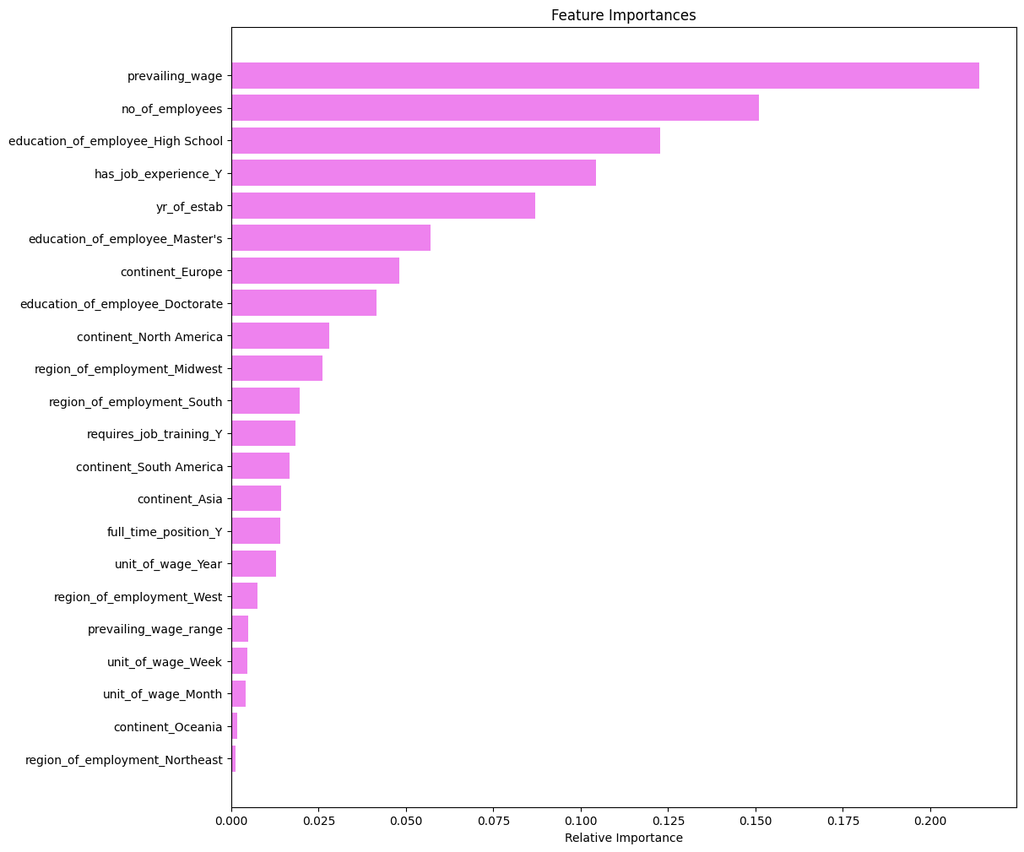

```python
feature_names = X_train.columns
importances =  tuned_gbm_un.feature_importances_
indices = np.argsort(importances)

plt.figure(figsize=(12, 12))
plt.title("Feature Importances")
plt.barh(range(len(indices)), importances[indices], color="violet", align="center")
plt.yticks(range(len(indices)), [feature_names[i] for i in indices])
plt.xlabel("Relative Importance")
plt.show()
```

```python
print("Below are the list of features in the decreasing order of importance \n\n")
print(
    pd.DataFrame(
        tuned_gbm_un.feature_importances_, columns=["Importance"], index=X_train.columns
    ).sort_values(by="Importance", ascending=False)
)
```

```
Below are the list of features in the decreasing order of importance


                                   Importance
prevailing_wage                         0.214
no_of_employees                         0.151
education_of_employee_High School       0.123
has_job_experience_Y                    0.104
yr_of_estab                             0.087
education_of_employee_Master's          0.057
continent_Europe                        0.048
education_of_employee_Doctorate         0.042
continent_North America                 0.028
region_of_employment_Midwest            0.026
region_of_employment_South              0.020
requires_job_training_Y                 0.018
continent_South America                 0.017
continent_Asia                          0.014
full_time_position_Y                    0.014
unit_of_wage_Year                       0.013
region_of_employment_West               0.007
prevailing_wage_range                   0.005
unit_of_wage_Week                       0.005
unit_of_wage_Month                      0.004
continent_Oceania                       0.002
region_of_employment_Northeast          0.001
```

# Business Insights and Conclusions

- The model performance can be improved, especially in terms of precision and F1 score and EasyVisa can use the model to predict the acceptance of new Visa applicants once the model is further improved.
- From the data, we saw that prevailing wage is the most important feature. We also saw that the yearly wage is the majority of the wage type.
- The next important feature is the no_of_employees of the organization. The higher the number of employees, the higher are the approvals.
- The next important feature is education. Visa approval success also depends on high school education of the applicant.
- The success of the visa approval also depends on other factors such as job experience of the applicant.
- Applicant's continent also plays an important role with Applicants from Europe seeing highest approval rates followed by North America.
- Region of employment also plays an important role. For example, the applicants whose region of employment as Midwest has higher chances of Visa acceptance. The next best region of employment is South.
- The features such as requires_job_training and full_time_position also play a small role in approval chances of the visa applicant.

```python
!jupyter nbconvert /content/drive/MyDrive/Colab Notebooks/Group6_CSCN8010_Final_Project.ipynb --to html
```

[output not shown]

[output cut: 137 more lines]

[output not shown]